# Regression for Prediction: A Brief, First Look at Supervised Learning

Nunyat Tefera

12/10/2001

## Introduction

### Heretofore, we have studied regression in the context of inference. We have sought to estimate regression parameters from sample data and to use these estimates to make inference on population parameters, using the techniques of ordinary least squares (OLS), test statistic and standard error calculation, confidence interval construction, and hypothesis testing. We have also seen, in our examination of logistic regression, that we can analyze binary response variables with an adjusted linear modeling framework that uses, on the left-hand side, the logit transformation of the binomial probabilities of the outcome variable, making possible the construction of confidence intervals and hypothesis testing for our estimates of predictor parameters. Regression, in the context of inference, aims to shed light on phenomena of interest, to help us understand (possibly causal) associations between predictor and outcome variables.

### In this assignment, we consider regression in the context of prediction. No longer are we so interested in understanding associations betweem predictor and response variables. Instead, our prime interest is in fashioning models that make predictions, as on-target and highly precise as possible, on values assumed by response variables that interest us. We seek ultimately to build and perfect regression models that we can put to use on data that are brand new, never before analyzed or studied.

## Setup

### In the code chunk(s) that follow(s), we load needed packages.

```r
library(openintro)
library(mlbench)
library(boot)
```

## Data

### In this assignment, the data we use originate from a famous, small data set: the Boston Housing data set. These data come from the U.S. Census Bureau’s 1970 Decennial Census and consist of measures within census tracts in the Boston Standard Metropolitan Statistical Area. See US Department of Commerce, Social and Economic Statistics Administration, Bureau of the Census, “Census Tracts, Boston Mass. Standard Metropolitan Statistical Area,” 1970 Census of Population and Housing, PHC(1)-29, May 1972. Perhaps the most famous use of these data assoicates with the work of researchers David Harrison Jr. and Daniel L. Rubinfeld, “Hedonic Housing Prices and the Demand for Clean Air,” Journal of Environmental Economics and Management 5, pp. 81-102, 1978. The actual data used by Harrison and Rubinfeld are easily available from the StatLib archive (http://lib.stat.cmu.edu/datasets/boston). The mlbench package contains a corrected version, BostonHousing2, of that original data set, and we use that corrected version here. Additional information can be had through invocation of ?BostonHousing2.

```r
data(BostonHousing2)
boston <- BostonHousing2
```

## Checking a first predictive model, with some notes on diagnostic plots

### We begin with an initial, fairly simple, and improvable regression model using the median home value (medv) as the outcome. Our right-side variables include crim (per capita crime rate for municipalities), chas (a variable indicating whether the Census tract borders the Charles River), age (a variable expressing proportions of owner-occupied housing stock constructed before 1940), and lstat (a complex variable equal to 0.5 X (the proportion of adults without any high school education plus the porportion of male employees who are laborers)), as predictors. For now we do not concern ourselves with how our predictors were selected:

```r
m1 <- glm(medv ~ crim + chas + age + lstat, data = boston)
summary(m1)
```

```
##
## Call:
## glm(formula = medv ~ crim + chas + age + lstat, data = boston)
##
## Deviance Residuals:
##     Min       1Q   Median       3Q      Max
## -15.594   -3.834   -1.319    1.932   24.224
##
## Coefficients:
##             Estimate Std. Error t value Pr(>|t|)
## (Intercept) 32.73813    0.73635  44.460  < 2e-16 ***
## crim        -0.07492    0.03543  -2.115   0.0350 *
## chas1        4.44525    1.07516   4.135 4.17e-05 ***
## age          0.02987    0.01220   2.448   0.0147 *
## lstat       -0.97132    0.05026 -19.326  < 2e-16 ***
## ---
## Signif. codes:  0 '***' 0.001 '**' 0.01 '*' 0.05 '.' 0.1 ' ' 1
##
## (Dispersion parameter for gaussian family taken to be 36.61201)
##
##     Null deviance: 42716  on 505  degrees of freedom
## Residual deviance: 18343  on 501  degrees of freedom
## AIC: 3264.7
##
## Number of Fisher Scoring iterations: 2
```

### 1. Given the summary just generated, what might lead you to think that we have here a useful model, for inference at least (and possibly for prediction)?

### This a useful model because it contains the mean and the median and the max. It also contains significant codes. It alao contains the null deviance and the residual deviance. It contains the values neccessary to see the model is useful.

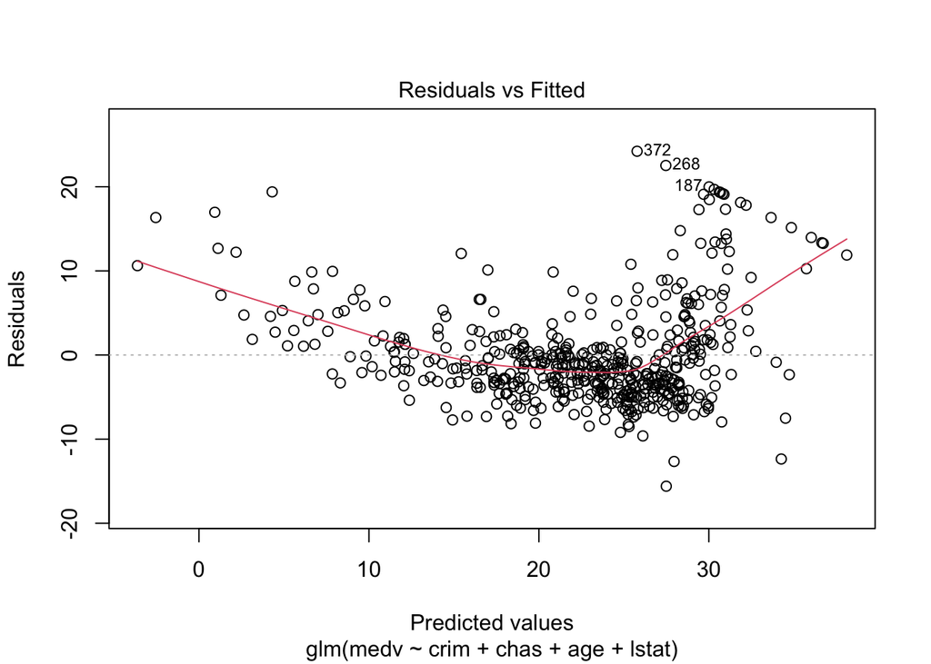

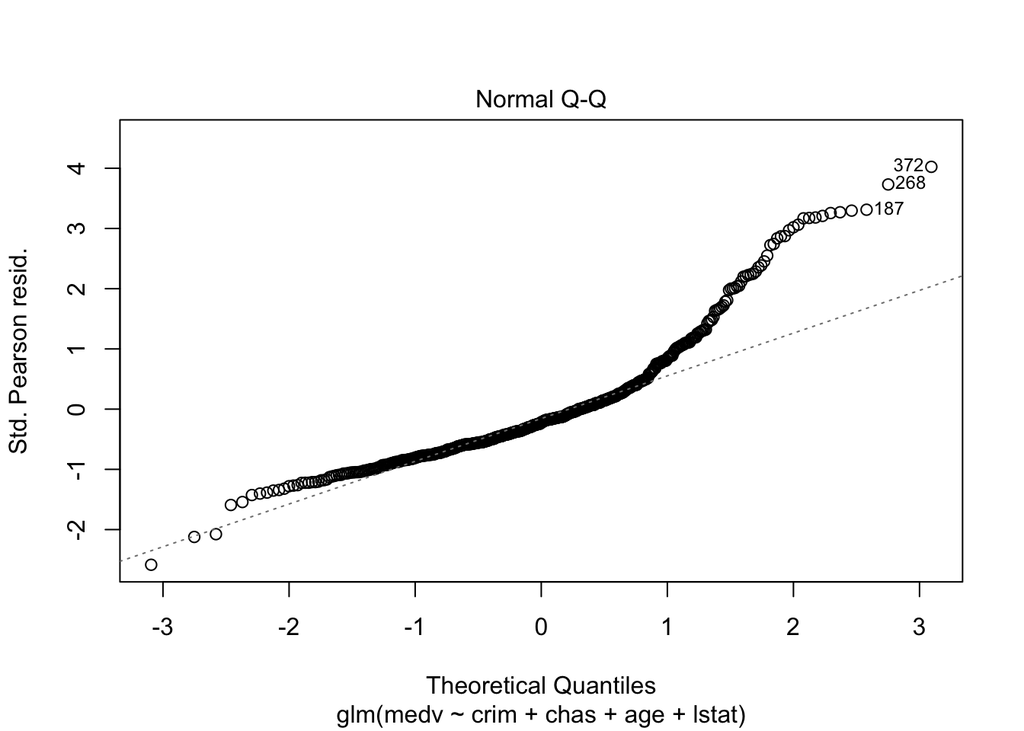

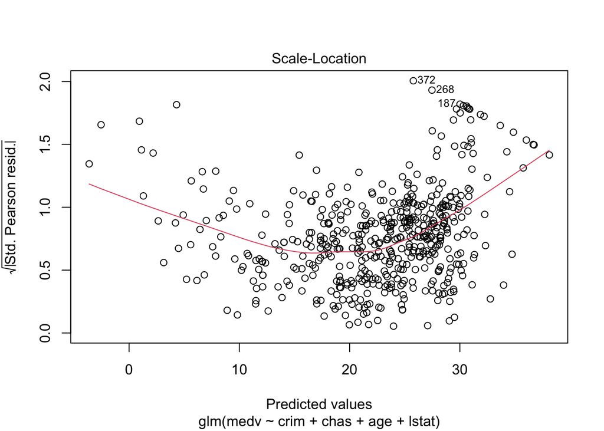

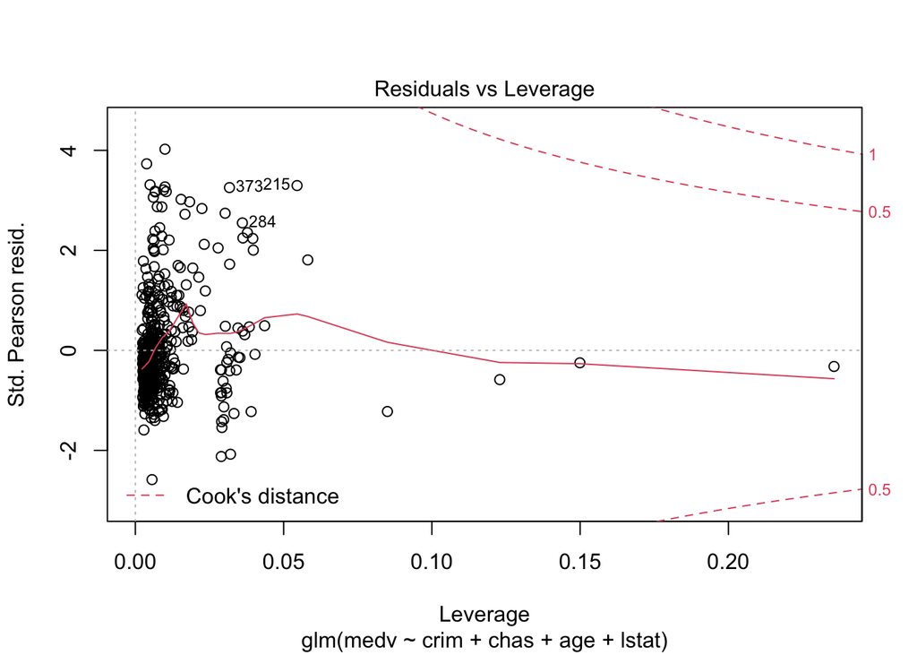

```r
plot(m1)
```

### In this problem it is not heading in the direction on the normal qq plot so the condition is not met. In addition the data set points are not centered around zero.

### Note the Residuals vs. Leverage plot. We have not seen such a plot in our work yet. What we have in our plot here is desirable – we wish to see the unbroken (undashed) maroon line hover about the zero line, and we hope to see no data point cross the 0.5 contour of Cook’s distance. Cook’s distance for a data point is a measure that reflects the degree to which deletion of that data point would alter the trajectory of the regression line.

### Now, we move on to our first prediction-oriented step. We can use the `predict` function to compute predicted home values in the 1970 Boston Census tracts based on our regression model, and to compare our predicted values with the actual observed values. This will offer additional insight into the usefulness of our first model:

```r
boston$pred1 <- predict(m1)
head(boston[,c(5,20)])
```

```
##   medv    pred1
## 1 24.0 29.84777
## 2 21.6 26.21468
## 3 34.7 30.64650
## 4 33.4 31.24791
## 5 36.2 29.17458
## 6 28.7 29.42848
```

### We see the actual observed values in the medv column, and the predicted values in the pred1 column. Can we improve upon this model? Likely, the answer is yes.

### We now fit an extended model that includes `lstat` squared as an additional predictor variable. We have the following (and note the use of the I() function):

```r
m2 <- glm(medv ~ crim + chas + age + lstat + I(lstat^2), data = boston)
summary(m2)
```

```
##
## Call:
## glm(formula = medv ~ crim + chas + age + lstat + I(lstat^2),
##     data = boston)
##
## Deviance Residuals:
##      Min        1Q    Median        3Q       Max
## -16.7800   -3.2266   -0.7439    2.5632   24.0745
##
## Coefficients:
##              Estimate Std. Error t value Pr(>|t|)
## (Intercept) 40.752917   0.849614  47.966  < 2e-16 ***
## crim        -0.128786   0.030343  -4.244 2.61e-05 ***
## chas1        3.662587   0.915025   4.003 7.21e-05 ***
## age          0.069733   0.010753   6.485 2.13e-10 ***
## lstat       -2.645215   0.127447 -20.755  < 2e-16 ***
## I(lstat^2)   0.050618   0.003631  13.939  < 2e-16 ***
## ---
## Signif. codes:  0 '***' 0.001 '**' 0.01 '*' 0.05 '.' 0.1 ' ' 1
##
## (Dispersion parameter for gaussian family taken to be 26.41852)
##
##     Null deviance: 42716  on 505  degrees of freedom
## Residual deviance: 13209  on 500  degrees of freedom
## AIC: 3100.6
##
## Number of Fisher Scoring iterations: 2
```

```r
anova(m2)
```

```
## Analysis of Deviance Table
##
## Model: gaussian, link: identity
##
## Response: medv
##
## Terms added sequentially (first to last)
##
##
##            Df Deviance Resid. Df Resid. Dev
## NULL                         505      42716
## crim        1   6440.8       504      36276
## chas        1   1010.4       503      35265
## age         1   3248.0       502      32017
## lstat       1  13674.5       501      18343
## I(lstat^2)  1   5133.4       500      13209
```

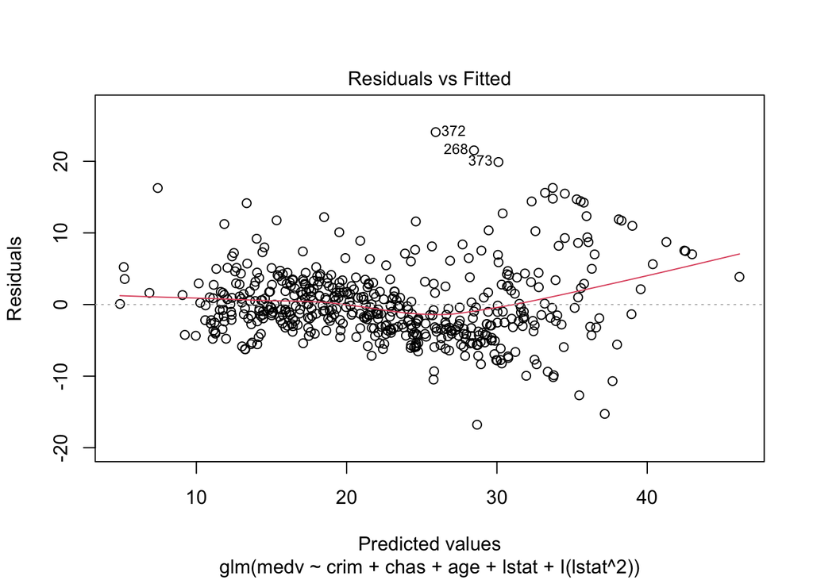

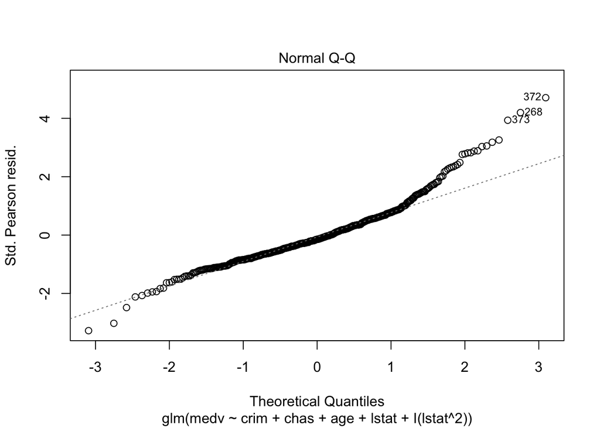

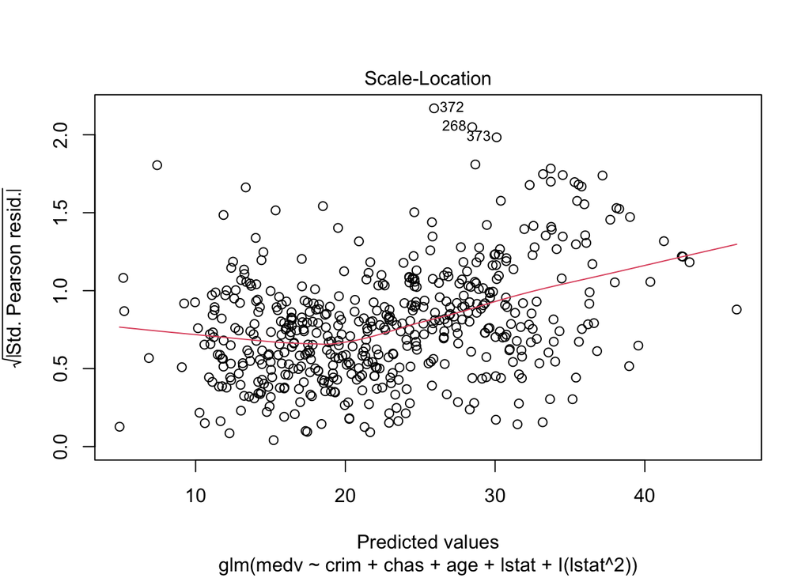

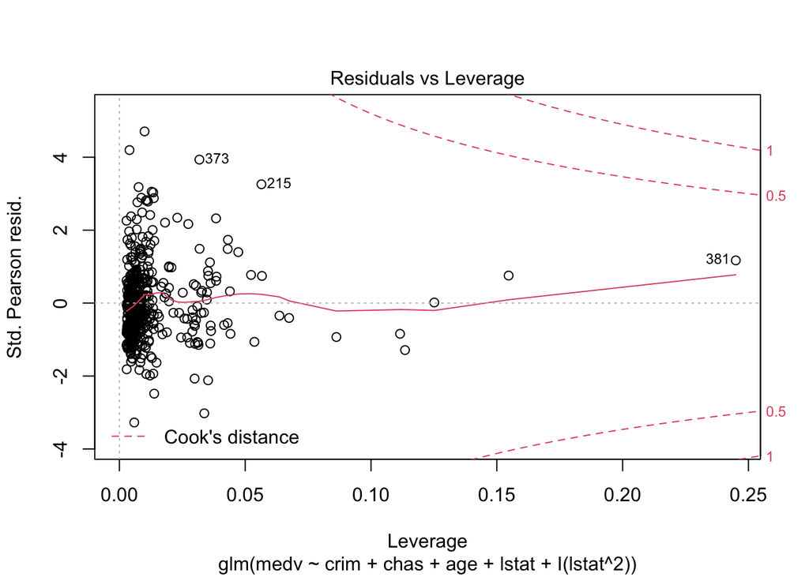

```r
plot(m2)
```

```r
boston$pred1 <- predict(m2)
head(boston[,c(5,20)])
```

```
##   medv    pred1
## 1 24.0 33.38086
## 2 21.6 26.30265
## 3 34.7 35.17194
## 4 33.4 36.60310
## 5 36.2 31.86255
## 6 28.7 32.43480
```

## Prediction and Supervised Learning

### Ideally, when we use regression primarily for prediction, our goal is to arrive at a model that can be deployed in analysis of brand-new data, comparable in nature to the data we used in researching our model, from the same or from a different source. Both models here were fitted using the full sample data set. If somehow we can use these Boston data to “train” a function or a model such that our final model well predicts median housing value on unobserved data, on some new data set, we’ve arrived.

### We use the term “supervised learning” to refer to prediction of values on some response variable of interest using a function or a model that incorporates (always or almost always) several, or at least a few, input or predictor variables. We create and refine models that make good predictions on the response variable of interest.

### Evaluating the prediction performance of our two models on observations from within the same data set gives us what is known in the discipline of supervised learning as the training error. We are “training” models using all our sample data. Here, we compute the training Mean Square Error for each of our two models.

```r
mean((predict(m1) - boston$medv)^2)
```

```
## [1] 36.25024
```

```r
mean((predict(m2) - boston$medv)^2)
```

```
## [1] 26.10525
```

### 5. Before reading on to the next paragraph, exactly what do you think the code chunk (two code chunks, if you are reading from the .html document) does (do)? Which of the two models would you guess performs best in prediction? After giving an answer, please see how your answer compares to what is given in the paragraph that follows.

### A: The chunk indicates a loss function and the lower the loss the better. Therefore the one that involves m2 is the best.

### We see in the prior code chunk(s) a particular expression of what we call a loss function. For each of the two models, for each observation, we compute the difference between the predicted value on the outcome variable and the actually observed value, and then we square the difference. We then we take the mean of the squared differences. The result is our loss, a metric indicating the goodness of our predictive model, incorporating elements of accuracy and precision. The smaller the loss, the better our predictive model.

## Train and test set

### The training error is the error associated with prediction on the data we used to train our model. Test error is something else. Test error is the error we obtain when we deploy our best-so-far model on brand new data. However, to get an estimate of the test error, we have to proceed differently from what we have just done with our training data. Namely we need to “hold out” some of our sample data when training our model so that we can use the hold-out portion for testing our best-so-far model.

### A very simple option is to split the data into a train and test set, with randomization. Here we use `sample` to prepare an 80 to 20 percent split of the BostonHousing2 data:

```r
set.seed(7345)
train <- sample(1:nrow(BostonHousing2), 0.8*nrow(BostonHousing2))
```

### We have seen the sample() function in action before. The resulting object gives us the row positions of the sampled elements. We use these positions to split the data into two subsets – again, the train and the test data sets.

```r
boston_train <- BostonHousing2[train,]
boston_test <- BostonHousing2[-train,]
```

### Now, we refit the previous regression two models, this time however using the training set only.

```r
m3 <- glm(medv ~ crim + chas + age + lstat, data = boston_train)
m4 <- glm(medv ~ crim + chas + age + lstat + I(lstat^2), data = boston_train)
```

### On this basis, we can use these models to predict median home values on the hold-out test portion of the BostonHousing2 data.

```r
pred3 <- predict(m3, newdata = boston_test)
pred4 <- predict(m4, newdata = boston_test)
```

### And we can evaluate the prediction performance on the test set.

```r
mean((pred3 - boston_test$medv)^2)
```

```
## [1] 46.83435
```

```r
mean((pred4 - boston_test$medv)^2)
```

```
## [1] 36.11249
```

### 6. Which of the models performs better?

### The better model is predict4 set because it has significantly less loss when the performance was evaLuated.

## Regression and CV

### Another (and better) evaluation approach involves what is known as cross-validation (CV), which for general linear models (GLMs) is implemented in the R function `cv.glm()`. cv.glm eliminates our need to create, manually, test and train data sets, as we did above. The default setting in cv.glm is to run what we call leave-one-out cross-validation (LOOCV). In LOOCV, we fit a model on training data that include all sample data observations, except one. Then we use the fitted model to predict the value on the outcome variable for the observation we have left out. We repeat this process n times, where n is the size of our sample. We compute an LOOVC error by taking the mean of the n loss values we compute (that is, by summing the loss for each of the n predictions, and then dividing that sum by n). More information is available by invoking `?cv.glm`.

```r
set.seed(3231)
cv.err <- cv.glm(boston, m1)
cv.err$delta
```

```
## [1] 37.27502 37.27399
```

### Our 2-tuple delta vector gives us, first, an unadjusted estimate of CV error, and second, an adjusted estimate. Note that here, under LOOCV, the two estimates are almost exactly the same. This is because the adjusted estimate incorporates a computation for bias that results when we create fewer than n estimates. Specifically, as the good folks at CRAN tell us, “The adjustment is designed to compensate for the bias introduced by not using leave-one-out cross-validation.” Of course we used precisely that technique, so we might expect that the two values here would show little difference. But, perhaps unexpectedly, we will see similarly very small difference in subsequent computations. This could indicate that the bias component (systematic error) to the error in the models we have fashioned is not great.

### We could also do what is known as 5-fold or 10-fold cross validation. Analogous to LOOCV, these approaches have us split our training data into K = five or ten data subsets. Then we train (fit) a model on four or nine of these subsets and use the fitted model to predict outcomes on the excluded-from-training fifth and tenth data subsets. Then we repeat the process, four or nine times, until each of the five or ten data subsets has been deployed as test data for the models we fit. We compute 5-fold and 10-fold CV error by taking the mean of the five or ten loss values compute. Again we use the R function cv.glm.

### So for 5-fold CV, we have the following, using the first of the models we created (m1):

```r
cv.err5 <- cv.glm(boston, m1, K = 5)
cv.err5$delta
```

```
## [1] 37.33478 37.21174
```

### And for 10-fold CV, we have the following, again for m1:

```r
cv.err10 <- cv.glm(boston, m1, K = 10)
cv.err10$delta
```

```
## [1] 37.07364 37.03004
```

### On this basis, we can now check whether the extended model m2 performs better than m1 when using hold-out sets for model evaluation.

```r
cv.err10.2 <- cv.glm(boston, m2, K = 10)
cv.err10.2$delta
```

```
## [1] 26.90636 26.86347
```